# Pneumonia Chest X-Ray Classification

Classifying pneumonia-infected chest x-ray scans using Convolutional Neural Network with Transfer Learning.

## Background

### Chest X-Ray Image Dataset

The dataset used for this task if from a [Kaggle dataset](https://www.kaggle.com/paultimothymooney/chest-xray-pneumonia) by Paul Mooney. It consists of two kinds of chest x-rays, those infected by pneumonia, and the other being normal. Our main goal is to distinguish which chest corresponds to pneumonia-infected ones and which aren't. Note that the dataset is highly imbalanced, like many medical image dataset are.

### fast.ai Library

fast.ai has just released its version 2 deep learning framework. It is bundled with tons of features which weren't available previously such as its brand new medical applications. Although this task isn't related to actually using the medical applications, it serves as a stepping-stone.

### fastbook

Aside from releasing its version 2 framework, fast.ai also released a companion-book dubbed fastbook. The book is available for free in the form of [Jupyter notebooks](https://github.com/fastai/fastbook), but one can also purchase a print version on [Amazon](https://www.amazon.com/Deep-Learning-Coders-fastai-PyTorch/dp/1492045527). More importantly, this task is applying the 7th Chapter of the book called **Training a State-of-the-Art Model**.

### Transfer Learning

Lastly, we applied Transfer Learning in this task, since I've seen it to perform better with it after a couple of runs. The particular model we'll be using is EfficientNetB3A, with weights from Ross Wightman's **timm** [library](https://github.com/rwightman/pytorch-image-models/blob/master/timm/models/efficientnet.py).

## Code

```python
import torch
import fastai
from fastai.vision.all import *
from fastai.vision.core import *
from fastai.callback import *
from fastai.metrics import *
import numpy as np
from sklearn.metrics import precision_score, recall_score, confusion_matrix
import matplotlib.pyplot as plt
from timm import create_model
```

### Load Data

The dataset is very imbalanced. Firstly, it has more pneumonia-infected chest x-rays compared to normal ones. Regardless, we've tried to oversample using PyTorch's `WeightedRandomSampler` as it didn't show much of an improvement. Secondly, it has a very small validation dataset - 16 images in total. As such, measuring the model by its validation accuracy seems unwise.

```python
path = Path("chest_xray/chest_xray")
```

#### Data Augmentation

First up in the loading process is data augmentation. This includes normalizing the images with Imagenet statistics (mean and std. dev.) since the pretrained model also used the same stats. Moreover, we shall apply default augmentative transforms provided by fast.ai, coupled with a `RandomResizedCrop`.

Augmenting our data helps the model to regularize and avoid overfitting when presented with new, unknown data.

```python
batch_tfms = [Normalize.from_stats(*imagenet_stats), *aug_transforms()]
```

```python
def get_dls(bs: int, size: int):
    '''
    Returns a pair of training and validation dataloaders.

            Parameters:
                    bs (int): Batch size
                    size (int): Size of images after resizing

            Returns:
                    Dataloaders of batch size `bs`
    '''
    dblock = DataBlock(blocks     = (ImageBlock, CategoryBlock),
                       get_items  = get_image_files,
                       get_y      = parent_label,
                       splitter   = GrandparentSplitter(valid_name='val'),
                       item_tfms  = RandomResizedCrop(size, min_scale=0.75),
                       batch_tfms = batch_tfms)
    return dblock.dataloaders(path, bs=bs, num_workers=0).cuda()
```

```python
dls = get_dls(64, 224)
```

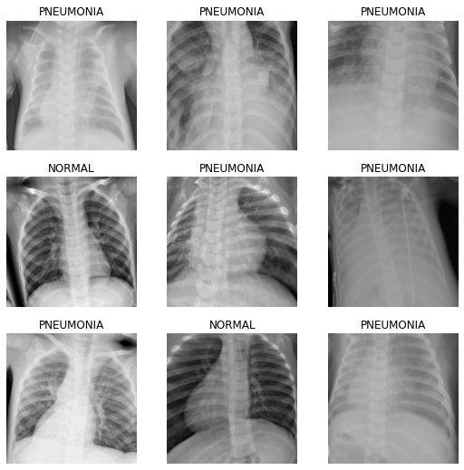

```python
dls.show_batch()
```

### Model

As mentioned, we'll be using a pretrained model called **EfficientNetB3A**. The few blocks of code below are from Zachary Mueller's **Practical-Deep-Learning-for-Coders-2.0** notebook tutorials. In particular, his [notebook](https://github.com/muellerzr/Practical-Deep-Learning-for-Coders-2.0/blob/master/Computer%20Vision/05_EfficientNet_and_Custom_Weights.ipynb) titled **05 EfficientNet and Custom Pretrained Models** showed how to create a timm body, load pretrained weights, create a model head accordingly, and combine the two together.

```python
def create_timm_body(arch: str, pretrained=True, cut=None):
    '''
    Returns the body of a timm model suited to fast.ai.

            Parameters:
                    arch (str): Architecture name
                    pretrained (bool): Load pretrained weights
                    cut: Rule when splitting model

            Returns:
                    A timm model splitted according to given rules and suited for fast.ai `Learner`
    '''
    model = create_model(arch, pretrained=pretrained)
    if cut is None:
        ll = list(enumerate(model.children()))
        cut = next(i for i,o in reversed(ll) if has_pool_type(o))
    if isinstance(cut, int):
        return nn.Sequential(*list(model.children())[:cut])
    elif callable(cut):
        return cut(model)
    else:
        raise NamedError("cut must be either integer or function")
```

```python
body = create_timm_body('efficientnet_b3a', pretrained=True)
```

Once the model has been split into `body`, we can designate its head according to the last layer size of `body` and point the `head` to as many classes as we have in our dataloaders (accessed via `dls.c`).

```python
nf = num_features_model(nn.Sequential(*body.children())) * (2)
head = create_head(nf, dls.c)
```

After creating the model here, we'll apply a **Kaiming Normal initialization** to the second half of the model. Kaiming He's normalization technique is introduced on this [paper](https://arxiv.org/abs/1502.01852).

```python
model = nn.Sequential(body, head)
apply_init(model[1], nn.init.kaiming_normal_)
```

We'll use `LabelSmoothingCrossEntropy` and `MixUp` callback as suggested in fastbook. Both the loss function and callback may contribute to improving the model's accuracy. You can find papers introducing Label Smoothing [here](https://arxiv.org/abs/1512.00567) and Mixup [here](https://arxiv.org/abs/1710.09412).

Label Smoothing and Mixup combats overfitting and regularizes the model further. Label Smoothing prevents our model from making sharp decisions on only 1 class, while Mixup augments our data by partially combining images from two sets of classes into one.

```python
learn = Learner(dls, model, loss_func=LabelSmoothingCrossEntropy(), metrics=accuracy, cbs=MixUp())
```

Since the model takes up a lot of GPU memory, using one GPU wasn't enough. So we split the computation to two GPUs using PyTorch's `DataParallel`.

```python
if torch.cuda.device_count() > 1:
    print("Let's use", torch.cuda.device_count(), "GPUs!")
    learn.model = nn.DataParallel(learn.model)
```

```
Let's use 2 GPUs!
```

### Training Model

Once everything has been setup, we can find a good learning rate to train the model.

```
SuggestedLRs(lr_min=0.006918309628963471, lr_steep=9.120108734350652e-05)
```

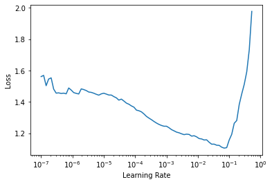

```python
learn.lr_find()
```

Here we'll train the model for 10 epochs with [one-cycle policy](https://arxiv.org/abs/1708.07120) with a learning rate of `6e-3`, add a `0.1` weight decay.

```python
learn.fit_one_cycle(10, 6e-3, wd=0.1, cbs=SaveModelCallback(fname='best-val-loss'))
learn.save('efficientnetb3a-1')
```

| epoch | train_loss | valid_loss | accuracy | time |
| --- | --- | --- | --- | --- |
| 0 | 0.762553 | 1.285270 | 0.500000 | 02:28 |
| 1 | 0.560403 | 1.788918 | 0.500000 | 02:27 |
| 2 | 0.497399 | 0.727971 | 0.562500 | 02:26 |
| 3 | 0.460750 | 0.842557 | 0.625000 | 02:25 |
| 4 | 0.532170 | 8.171339 | 0.625000 | 02:25 |
| 5 | 0.493482 | 2.005133 | 0.687500 | 02:30 |
| 6 | 0.435214 | 0.956962 | 0.562500 | 03:33 |
| 7 | 0.397469 | 0.727003 | 0.562500 | 03:12 |
| 8 | 0.377309 | 0.713967 | 0.625000 | 02:27 |
| 9 | 0.380401 | 0.636497 | 0.625000 | 02:25 |

```
Better model found at epoch 0 with valid_loss value: 1.2852699756622314.
Better model found at epoch 2 with valid_loss value: 0.7279710173606873.
Better model found at epoch 7 with valid_loss value: 0.7270027995109558.
Better model found at epoch 8 with valid_loss value: 0.7139670252799988.
Better model found at epoch 9 with valid_loss value: 0.6364966630935669.
```

```
Path('models/efficientnetb3a-1.pth')
```

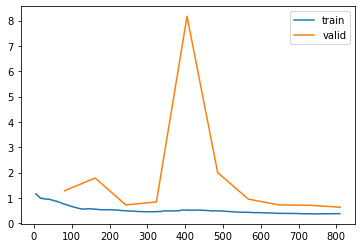

```python
learn.recorder.plot_loss()
```

### Testing Model

As mentioned, the validation dataset is too small to measure our model's performance. Fortunately, the dataset gave a large enough test dataset which we'll be using.

#### Load Test Data

We create a test dataloader and substitute the old validation dataset with it.

```python
def get_test_dls(bs: int, size: int, test_folder: str):
    '''
    Returns a pair of training and testing dataloaders.

            Parameters:
                    bs (int): Batch size
                    size (int): Size of images after resizing
                    test_folder (str): Path to test folder

            Returns:
                    Dataloaders of batch size `bs`
    '''
    dblock = DataBlock(blocks     = (ImageBlock, CategoryBlock),
                       get_items  = get_image_files,
                       get_y      = parent_label,
                       splitter   = GrandparentSplitter(valid_name=test_folder),
                       item_tfms  = Resize(size),
                       batch_tfms = batch_tfms)
    return dblock.dataloaders(path, bs=bs, num_workers=0).cuda()
```

```python
test_dl = get_test_dls(64, 224, 'test')
```

```python
learn.dls = test_dl
```

#### Test Accuracy

```python
preds, targs = learn.get_preds()
accuracy(preds, targs)
```

```
tensor(0.9231)
```

### Analyze Results

The model achieved a 92% accuracy for the test data. However, using accuracy as a measure of performance in an unbalanced dataset is unwise. If say we have 95 normal chest images and 5 pneumonia-infected ones, freely guessing 100 of them to be normal would still output a high 95% accuracy. Hence, **Precision** and **Recall** is a better metric to use in this case.

According to the Scikit Learn [docs](https://scikit-learn.org/stable/modules/generated/sklearn.metrics.precision_score.html#sklearn.metrics.precision_score), precision is *intuitively the ability of the classifier not to label as positive a sample that is negative*. Whereas recall is *intuitively the ability of the classifier to find all the positive samples.*

We can plot the results of the test predictions and visualize using a confusion matrix. In fact, plotting such diagram is available in the fast.ai library. However, for some reason we couldn't get it to work in this new update. Thus, we decided to simply copy the actual fast.ai `interpret` [code found here](https://github.com/fastai/fastai/blob/master/fastai/interpret.py#L51) and modify it to fix the issue.

We found that the `confusion_matrix` code broke the plotting process which is dependent on it. To fix the issue, We've replaced `confusion_matrix` with [Scitkit Learn](https://scikit-learn.org/stable/modules/generated/sklearn.metrics.confusion_matrix.html?highlight=confusion_matrix)'s. Lastly, we specified the function to also print the recall and precision metrics, both of which are also from Scikit Learn.

```python
def plot_confusion_matrix(y_pred, y_true, vocab):
    '''
    Plots a confusion matrix given ground truth and predictions.

            Parameters:
                    y_pred: Class predictions
                    y_true: Ground truth classes
                    vocab: Vocabulary of classes

            Returns:
                    None
    '''
    y_pred = y_pred.argmax(dim=-1)
    cm = confusion_matrix(y_true, y_pred)

    fig = plt.figure(figsize=(8,8), dpi=60)
    plt.imshow(cm, interpolation='nearest', cmap="Blues")
    plt.title("Confusion Matrix")
    tick_marks = np.arange(len(vocab))
    plt.xticks(tick_marks, vocab, rotation=90)
    plt.yticks(tick_marks, vocab, rotation=0)

    thresh = cm.max() / 2.
    for i, j in itertools.product(range(cm.shape[0]), range(cm.shape[1])):
        coeff = f'{cm[i, j]}'
        plt.text(j, i, coeff, horizontalalignment="center", verticalalignment="center", color="white" if cm[i, j] > thresh else "black")

    ax = fig.gca()
    ax.set_ylim(len(vocab)-.5,-.5)

    plt.tight_layout()
    plt.ylabel('Actual')
    plt.xlabel('Predicted')
    plt.grid(False)

    print(f"Precision: {precision_score(y_true, y_pred):.3f}")
    print(f"Recall: {recall_score(y_true, y_pred):.3f}")
```

```
Precision: 0.896
Recall: 0.992
```

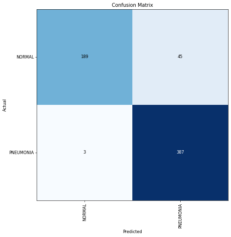

```python
plot_confusion_matrix(preds, targs, dls.vocab)
```

The model achieved 89% precision and 99% recall!